# Análisis Exploratorio de Datos (EDA) - Proyecto de Transporte

### Objetivos del Proyecto y Definición de Variables

El objetivo principal de este proyecto es desarrollar un modelo basado en **Máquinas de Vectores de Soporte (SVM)** para predecir el **modo de transporte** utilizado por un individuo en función de los datos recopilados por sensores de dispositivos móviles. Se busca analizar cómo las diferentes señales captadas por el acelerómetro, giróscopo, barómetro, GPS y magnetómetro pueden ser utilizadas para inferir con precisión el medio de transporte en uso.

Para lograr esto, se cuenta con un conjunto de datos que incluye:

1. **Registro Temporal**
   - Cada observación está asociada a un instante de tiempo específico.
2. **Datos de Movimiento y Orientación**
   - **Acelerómetro**: Componentes X, Y, Z del vector aceleración.
   - **Giróscopo**: Velocidad angular en los ejes X, Y, Z y su derivada.
   - **Matriz de Rotación y Cuaterniones**: Representan la orientación tridimensional del dispositivo.
3. **Datos de Ubicación y Contexto**
   - **GPS**: Coordenadas de latitud y longitud, velocidad, altitud y rumbo.
   - **Presión Atmosférica**: Valores obtenidos del barómetro, junto con la altitud relativa.
   - **Campo Magnético Terrestre**: Medición en los ejes X, Y, Z.
4. **Variables Categóricas**
   - **Modo de Transporte**: La categoría que se busca predecir (caminar, bicicleta, automóvil, etc.).
   - **Nivel de Confianza**: Un indicador de la precisión estimada para la clasificación del transporte en los datos originales.

### Alcance del Análisis

El análisis exploratorio de datos (EDA) busca comprender la estructura del dataset, identificar patrones y evaluar la calidad de los datos antes de proceder con el modelado. Se incluyen tareas como:

- **Identificación y tratamiento de outliers univariantes y multivariantes.**
- **Evaluación de la normalidad y distribución de las variables.**
- **Exploración de la correlación entre variables para determinar redundancias o relaciones clave.**
- **Selección de variables relevantes para el modelo.**

# **1. Carga de librerías**

```r
# Lista de paquetes necesarios
necessary_packages <- c("dplyr", "ggplot2", "DataExplorer", "naniar",
                        "moments", "psych", "caret", "lubridate", "chemometrics")

# Instalar paquetes que no están instalados
new_packages <- necessary_packages[!(necessary_packages %in% installed.packages()[, "Package"])]
if (length(new_packages) > 0) {
  install.packages(new_packages)
}

# Cargar todos los paquetes
lapply(necessary_packages, library, character.only = TRUE)
```

[output not shown]

```r
# Cargar las librerías
library(lubridate)
library(dplyr)
library(ggplot2)
library(naniar)
library(moments)
library(psych)
library(caret)
library(reshape2)
library(geosphere)
library(zoo)
# Cargar librerías necesarias
library(ggplot2)
library(gridExtra) # Para organizar múltiples gráficos
library(ggpubr)    # Para Q-Q plots
library(chemometrics)
library(mice)
library(tidyr)
library(tidyverse)
library(cowplot)
```

# 2. Cargar el dataset

```r
# Ruta del archivo CSV (modificar según tu sistema)
ruta_dataset <- "100Hz-v5_20240203_115342_10s-coche-urbano.csv"

data <- read.csv(ruta_dataset, fileEncoding = "EUC-KR")

# Resumen del dataset
cat("### Información General del Dataset")
```

```
### Información General del Dataset
```

```r
dim(data) # Dimensiones del dataset
```

```
[1] 5261   44
```

```r
str(data) # Estructura del dataset
```

```
'data.frame':   5261 obs. of  44 variables:
 $ Timestamp               : chr  "03-Feb-2024 12:01:11.664" "03-Feb-2024 12:01:11.674" "03-Feb-2024 12:01:11.684" "03-Feb-2024 12:01:11.694" ...
 $ accelX.g.               : num  0.0559 0.0505 0.0698 0.0722 0.0561 0.0488 0.0488 0.0488 0.0754 0.0754 ...
 $ accelY.g.               : num  0.0697 0.072 0.0756 0.0719 0.07 0.0699 0.0699 0.0699 0.0729 0.0729 ...
 $ accelZ.g.               : num  -0.985 -0.987 -0.983 -0.983 -0.988 ...
 $ accelUserX.g.           : num  0.0029 -0.0132 -0.0004 0.0133 -0.0142 -0.0143 -0.0022 -0.0022 0.0149 0.004 ...
 $ accelUserY.g.           : num  -0.0249 -0.0253 -0.0209 -0.0217 -0.0254 -0.0254 -0.0253 -0.0253 -0.0227 -0.024 ...
 $ accelUserZ.g.           : num  0.0123 0.0063 0.0091 0.0112 0.0059 0.0059 0.0138 0.0138 0.0182 0.0096 ...
 $ gyroX.rad.s.            : num  -0.0316 -0.0297 -0.0306 -0.0318 -0.0338 -0.0338 -0.0304 -0.0304 -0.0349 -0.031 ...
 $ gyroY.rad.s.            : num  0.0027 0.0246 0 -0.0104 0.0247 0.0247 0.0041 0.0041 -0.0201 0.012 ...
 $ gyroZ.rad.s.            : num  -0.0084 -0.0089 -0.0072 -0.0103 -0.0082 -0.0082 -0.0086 -0.0086 -0.0072 -0.0064 ...
 $ Roll.rads.              : num  0.0622 0.0623 0.0623 0.0622 0.0623 0.0624 0.0625 0.0625 0.0623 0.0622 ...
 $ Pitch.rads.             : num  -0.0957 -0.0957 -0.0957 -0.0957 -0.0957 -0.0957 -0.0956 -0.0956 -0.0957 -0.0957 ...
 $ Yaw.rads.               : num  -2.42 -2.42 -2.42 -2.42 -2.42 ...
 $ m11                     : num  -0.754 -0.754 -0.754 -0.754 -0.754 ...
```

[output cut: 30 more lines]

```r
summary(data) # Resumen estadístico básico
```

```
  Timestamp           accelX.g.          accelY.g.          accelZ.g.       accelUserX.g.       accelUserY.g.     accelUserZ.g.       gyroX.rad.s.       gyroY.rad.s.        gyroZ.rad.s.        Roll.rads.
 Length:5261        Min.   :-0.31520   Min.   :-0.20890   Min.   :-1.2011   Min.   :-0.328800   Min.   :-0.2590   Min.   :-0.19690   Min.   :-0.12970   Min.   :-0.563700   Min.   :-0.50970   Min.   :0.01790
 Class :character   1st Qu.: 0.05290   1st Qu.: 0.06840   1st Qu.:-0.9903   1st Qu.:-0.013500   1st Qu.:-0.0213   1st Qu.: 0.00370   1st Qu.:-0.03440   1st Qu.:-0.014300   1st Qu.:-0.01200   1st Qu.:0.06240
 Mode  :character   Median : 0.06460   Median : 0.07310   Median :-0.9816   Median :-0.001200   Median :-0.0127   Median : 0.01260   Median :-0.03070   Median : 0.004500   Median :-0.00860   Median :0.06330
                    Mean   : 0.05673   Mean   : 0.06942   Mean   :-0.9814   Mean   :-0.008937   Mean   :-0.0151   Mean   : 0.01264   Mean   :-0.03026   Mean   : 0.006523   Mean   :-0.03725   Mean   :0.06594
                    3rd Qu.: 0.07650   3rd Qu.: 0.09550   3rd Qu.:-0.9724   3rd Qu.: 0.009400   3rd Qu.: 0.0069   3rd Qu.: 0.02130   3rd Qu.:-0.02440   3rd Qu.: 0.027100   3rd Qu.:-0.00700   3rd Qu.:0.08170
                    Max.   : 0.44160   Max.   : 0.26360   Max.   :-0.7747   Max.   : 0.335200   Max.   : 0.1754   Max.   : 0.22620   Max.   : 0.08060   Max.   : 0.567300   Max.   : 0.02440   Max.   :0.09420
  Pitch.rads.         Yaw.rads.           m11               m12               m13                m21               m22               m23                m31                  m32               m33               qX
 Min.   :-0.11910   Min.   :-3.138   Min.   :-0.9989   Min.   :-0.7394   Min.   :-0.09360   Min.   :-0.6368   Min.   :-0.9951   Min.   :-0.11880   Min.   :-0.1005000   Min.   :-0.1397   Min.   :0.9902   Min.   :0.00650
 1st Qu.:-0.09340   1st Qu.:-2.405   1st Qu.:-0.7472   1st Qu.:-0.6830   1st Qu.:-0.08140   1st Qu.: 0.6646   1st Qu.:-0.7419   1st Qu.:-0.09320   1st Qu.:-0.0039000   1st Qu.:-0.1134   1st Qu.:0.9933   1st Qu.:0.01320
 Median :-0.08670   Median :-2.400   Median :-0.7403   Median :-0.6693   Median :-0.06300   Median : 0.6722   Median :-0.7353   Median :-0.08660   Median : 0.0080000   Median :-0.1067   Median :0.9941   Median :0.01460
 Mean   :-0.08462   Mean   :-2.133   Mean   :-0.7464   Mean   :-0.6024   Mean   :-0.06564   Mean   : 0.6060   Mean   :-0.7417   Mean   :-0.08451   Mean   : 0.0007774   Mean   :-0.1056   Mean   :0.9940   Mean   :0.01737
 3rd Qu.:-0.07680   3rd Qu.:-2.365   3rd Qu.:-0.7267   3rd Qu.:-0.6597   3rd Qu.:-0.06210   3rd Qu.: 0.6867   3rd Qu.:-0.7214   3rd Qu.:-0.07670   3rd Qu.: 0.0124000   3rd Qu.:-0.1011   3rd Qu.:0.9946   3rd Qu.:0.02260
 Max.   :-0.04480   Max.   : 3.141   Max.   :-0.6679   Max.   : 0.6437   Max.   :-0.01770   Max.   : 0.7442   Max.   :-0.6632   Max.   :-0.04480   Max.   : 0.0209000   Max.   :-0.0645   Max.   :0.9979   Max.   :0.03530
       qY                qZ                qW               Lat             Long         Speed.m.s.     TrueHeading         Alt.m.      HorizontalAccuracy.m. VerticalAccuracy.m.     Course       ActivityType
 Min.   :0.02940   Min.   :-0.9985   Min.   :-0.3413   Min.   :41.39   Min.   :2.154   Min.   :0.000   Min.   : 54.70   Min.   :48.13   Min.   :16            Min.   :3           Min.   : 42.40   Length:5261
 1st Qu.:0.04930   1st Qu.:-0.9330   1st Qu.: 0.3547   1st Qu.:41.39   1st Qu.:2.154   1st Qu.:0.000   1st Qu.: 54.70   1st Qu.:48.63   1st Qu.:16            1st Qu.:3           1st Qu.: 44.20   Class :character
 Median :0.05130   Median :-0.9314   Median : 0.3601   Median :41.39   Median :2.154   Median :1.781   Median : 55.70   Median :48.66   Median :16            Median :3           Median : 44.20   Mode  :character
 Mean   :0.05095   Mean   :-0.9329   Mean   : 0.3252   Mean   :41.39   Mean   :2.154   Mean   :3.024   Mean   : 60.08   Mean   :48.60   Mean   :16            Mean   :3           Mean   : 48.35
 3rd Qu.:0.05480   3rd Qu.:-0.9275   3rd Qu.: 0.3692   3rd Qu.:41.39   3rd Qu.:2.155   3rd Qu.:6.167   3rd Qu.: 55.70   3rd Qu.:48.66   3rd Qu.:16            3rd Qu.:3           3rd Qu.: 45.40
 Max.   :0.06700   Max.   :-0.9116   Max.   : 0.4068   Max.   :41.40   Max.   :2.155   Max.   :8.996   Max.   :143.60   Max.   :48.66   Max.   :16            Max.   :3           Max.   :133.50
 ActivityConfidence Pressure.kilopascals. RelativeAltitude.meters.   magX.뜻T.       magY.뜻T.       magZ.뜻T.       calMagX.뜻T.     calMagY.뜻T.     calMagZ.뜻T.
 Length:5261        Min.   :102.5         Min.   :35.90            Min.   :159.0   Min.   :51.64   Min.   :-617.9   Min.   :-24.77   Min.   :-14.57   Min.   :-1.460
 Class :character   1st Qu.:102.5         1st Qu.:35.94            1st Qu.:165.1   1st Qu.:80.05   1st Qu.:-614.0   1st Qu.:-17.26   1st Qu.: 14.16   1st Qu.: 1.531
 Mode  :character   Median :102.5         Median :36.19            Median :166.1   Median :80.39   Median :-613.6   Median :-16.46   Median : 14.43   Median : 2.219
                    Mean   :102.5         Mean   :36.48            Mean   :166.0   Mean   :79.15   Mean   :-613.5   Mean   :-16.79   Mean   : 13.21   Mean   : 2.371
                    3rd Qu.:102.5         3rd Qu.:36.90            3rd Qu.:167.3   3rd Qu.:81.12   3rd Qu.:-612.8   3rd Qu.:-15.66   3rd Qu.: 15.09   3rd Qu.: 3.313
                    Max.   :102.5         Max.   :37.81            Max.   :170.5   Max.   :85.46   Max.   :-609.3   Max.   :-10.69   Max.   : 19.58   Max.   : 7.114
```

Visualizamos que las columnas de Horizontal Accuracy y Vertical Accuracy tienen variables constantes, lo que se tendrán que eliminar. También se eliminarán las columnas de Timestamp, Lat, Long, Speed, Alt.m, Course ya que deberemos tener las mismas columnas en todos los datasets.

#### 2.1. Eliminar Timestamp, Lat, Long, speed.m.s., Alt.m., Course, TrueHeading, HorizontalAccuracy.m., VerticalAccuracy.m.

```r
data <- data %>% select(-Timestamp)
data <- data %>% select(-Lat)
data <- data %>% select(-Long)
data <- data %>% select(-Speed.m.s.)
data <- data %>% select(-Alt.m.)
data <- data %>% select(-Course)
data <- data %>% select(-TrueHeading)
data <- data %>% select(-HorizontalAccuracy.m.)
data <- data %>% select(-VerticalAccuracy.m.)
```

```r
colnames(data)[colnames(data) == "magX.뜻.T."] <- "magX.μT"
colnames(data)[colnames(data) == "magY.뜻.T."] <- "magY.μT"
colnames(data)[colnames(data) == "magZ.뜻.T."] <- "magZ.μT"
colnames(data)[colnames(data) == "calMagX.뜻.T."] <- "calMagX.μT"
colnames(data)[colnames(data) == "calMagY.뜻.T."] <- "calMagY.μT"
colnames(data)[colnames(data) == "calMagZ.뜻.T."] <- "calMagZ.μT"
```

```r
data$ActivityType <- "Coche Urbano 100"
```

Para la columna de ActivityType deberá estar en español y con las frase ‘Coche Urbano 100’

```r
data$ActivityType <- "Coche Urbano 100"
```

```r
head(data)
```

|  | accelX.g. | accelY.g. | accelZ.g. | accelUserX.g. | accelUserY.g. | accelUserZ.g. | gyroX.rad.s. | gyroY.rad.s. | gyroZ.rad.s. | Roll.rads. | Pitch.rads. | Yaw.rads. | m11 | m12 | m13 | m21 | m22 | m23 | m31 | m32 | m33 | qX | qY | qZ | qW | ActivityType | ActivityConfidence | Pressure.kilopascals. | RelativeAltitude.meters. | … |
| --- | --- | --- | --- | --- | --- | --- | --- | --- | --- | --- | --- | --- | --- | --- | --- | --- | --- | --- | --- | --- | --- | --- | --- | --- | --- | --- | --- | --- | --- | --- |
| 1 | 0.0559 | 0.0697 | -0.9846 | 0.0029 | -0.0249 | 0.0123 | -0.0316 | 0.0027 | -0.0084 | 0.0622 | -0.0957 | -2.4205 | -0.7536 | -0.6545 | -0.0619 | 0.6572 | -0.7477 | -0.0956 | 0.0163 | -0.1127 | 0.9935 | 0.0122 | 0.0557 | -0.9347 | 0.3508 | Coche Urbano 100 | High | 102.529 | 35.9144 | … |
| 2 | 0.0505 | 0.0720 | -0.9868 | -0.0132 | -0.0253 | 0.0063 | -0.0297 | 0.0246 | -0.0089 | 0.0623 | -0.0957 | -2.4206 | -0.7536 | -0.6544 | -0.0620 | 0.6571 | -0.7477 | -0.0956 | 0.0162 | -0.1128 | 0.9935 | 0.0123 | 0.0557 | -0.9347 | 0.3508 | Coche Urbano 100 | High | 102.529 | 35.9144 | … |
| 3 | 0.0698 | 0.0756 | -0.9828 | -0.0004 | -0.0209 | 0.0091 | -0.0306 | 0.0000 | -0.0072 | 0.0623 | -0.0957 | -2.4206 | -0.7536 | -0.6544 | -0.0620 | 0.6571 | -0.7477 | -0.0956 | 0.0162 | -0.1128 | 0.9935 | 0.0123 | 0.0557 | -0.9347 | 0.3508 | Coche Urbano 100 | High | 102.529 | 35.9144 | … |
| 4 | 0.0722 | 0.0719 | -0.9830 | 0.0133 | -0.0217 | 0.0112 | -0.0318 | -0.0104 | -0.0103 | 0.0622 | -0.0957 | -2.4206 | -0.7536 | -0.6544 | -0.0619 | 0.6571 | -0.7477 | -0.0956 | 0.0162 | -0.1127 | 0.9935 | 0.0122 | 0.0557 | -0.9347 | 0.3508 | Coche Urbano 100 | High | 102.529 | 35.9144 | … |
| 5 | 0.0561 | 0.0700 | -0.9884 | -0.0142 | -0.0254 | 0.0059 | -0.0338 | 0.0247 | -0.0082 | 0.0623 | -0.0957 | -2.4207 | -0.7537 | -0.6543 | -0.0620 | 0.6570 | -0.7478 | -0.0955 | 0.0161 | -0.1127 | 0.9935 | 0.0123 | 0.0557 | -0.9347 | 0.3507 | Coche Urbano 100 | High | 102.529 | 35.9144 | … |
| 6 | 0.0488 | 0.0699 | -0.9858 | -0.0143 | -0.0254 | 0.0059 | -0.0338 | 0.0247 | -0.0082 | 0.0624 | -0.0957 | -2.4207 | -0.7537 | -0.6543 | -0.0621 | 0.6570 | -0.7478 | -0.0955 | 0.0161 | -0.1128 | 0.9935 | 0.0123 | 0.0557 | -0.9347 | 0.3507 | Coche Urbano 100 | High | 102.529 | 35.9144 | … |

# 3. Estadísticas Descriptivas

Las estadísticas descriptivas ofrecen una visión inicial sobre el rango, la distribución y los valores típicos de las variables. Esto permite identificar patrones generales y posibles anomalías.

## **3.1 Variables Numéricas**

Se analizan las variables numéricas mediante histogramas y medidas descriptivas para evaluar su distribución y detectar valores atípicos.

```r
# Seleccionar columnas numéricas
num_data <- data %>% select(where(is.numeric))

# Verificar si hay columnas numéricas
if (ncol(num_data) > 0) {
  cat("### Estadísticas para Variables Numéricas\n")

  # Imprimir estadísticas descriptivas básicas
  print(describe(num_data)) # Estadísticas básicas

} else {
  cat("No hay variables numéricas en el dataset.\n")
}
```

```
### Estadísticas para Variables Numéricas
```

|  | vars | n | mean | sd | median | trimmed | mad | min | max | range | skew | kurtosis | se |
| --- | --- | --- | --- | --- | --- | --- | --- | --- | --- | --- | --- | --- | --- |
| accelX.g. | 1 | 5261 | 0.06 | 0.06 | 0.06 | 0.06 | 0.02 | -0.32 | 0.44 | 0.76 | -1.57 | 6.70 | 0.00 |
| accelY.g. | 2 | 5261 | 0.07 | 0.07 | 0.07 | 0.08 | 0.02 | -0.21 | 0.26 | 0.47 | -1.28 | 3.99 | 0.00 |
| accelZ.g. | 3 | 5261 | -0.98 | 0.04 | -0.98 | -0.98 | 0.01 | -1.20 | -0.77 | 0.43 | -0.13 | 4.16 | 0.00 |
| accelUserX.g. | 4 | 5261 | -0.01 | 0.05 | 0.00 | 0.00 | 0.02 | -0.33 | 0.34 | 0.66 | -1.35 | 7.19 | 0.00 |
| accelUserY.g. | 5 | 5261 | -0.02 | 0.06 | -0.01 | -0.01 | 0.02 | -0.26 | 0.18 | 0.43 | -1.07 | 3.48 | 0.00 |
| accelUserZ.g. | 6 | 5261 | 0.01 | 0.04 | 0.01 | 0.01 | 0.01 | -0.20 | 0.23 | 0.42 | -0.10 | 4.41 | 0.00 |
| gyroX.rad.s. | 7 | 5261 | -0.03 | 0.02 | -0.03 | -0.03 | 0.01 | -0.13 | 0.08 | 0.21 | 0.02 | 3.66 | 0.00 |
| gyroY.rad.s. | 8 | 5261 | 0.01 | 0.08 | 0.00 | 0.01 | 0.03 | -0.56 | 0.57 | 1.13 | 0.19 | 6.57 | 0.00 |
| gyroZ.rad.s. | 9 | 5261 | -0.04 | 0.10 | -0.01 | -0.01 | 0.00 | -0.51 | 0.02 | 0.53 | -3.39 | 10.44 | 0.00 |
| Roll.rads. | 10 | 5261 | 0.07 | 0.02 | 0.06 | 0.07 | 0.01 | 0.02 | 0.09 | 0.08 | -0.30 | 0.02 | 0.00 |

[output cut: 23 more lines]

```r
NA
```

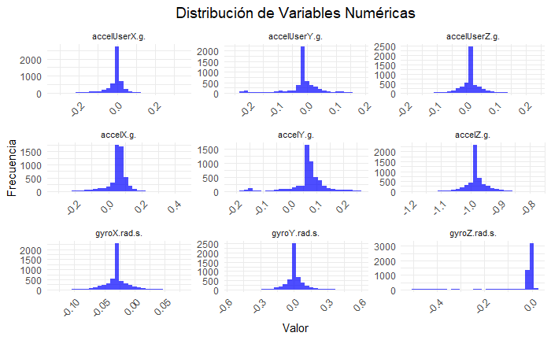

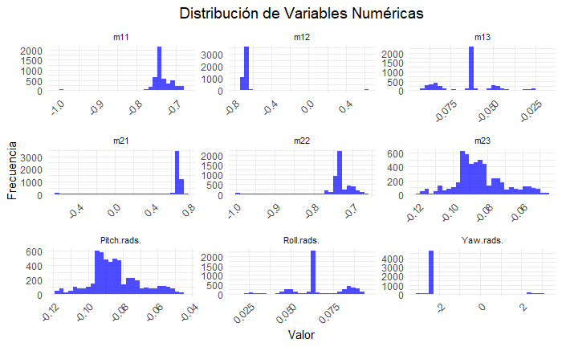

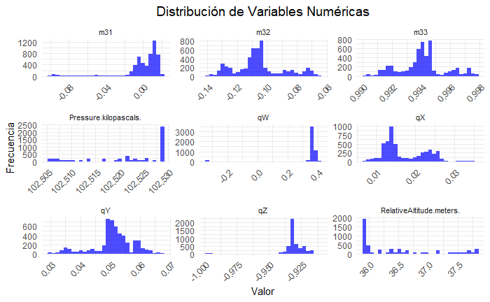

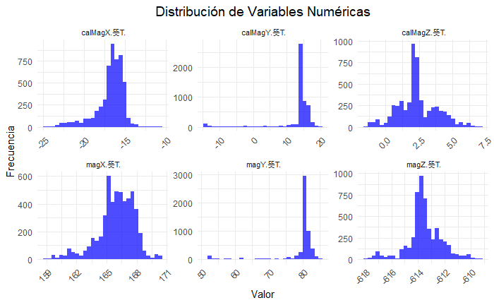

```r
# Instalar y cargar tidyr si es necesario
if (!requireNamespace("tidyr", quietly = TRUE)) {
  install.packages("tidyr")
}
library(tidyr)

# Visualización: Histogramas de Variables Numéricas
# Visualización: Histogramas de Variables Numéricas
# Dividir las variables en grupos de 9
variable_groups <- split(names(num_data), ceiling(seq_along(names(num_data)) / 9))

for (group in variable_groups) {
  # Filtrar las variables del grupo actual
  group_data <- num_data %>% select(all_of(group))

  # Convertir a formato largo
  group_data_long <- group_data %>%
    pivot_longer(cols = everything(), names_to = "Variable", values_to = "Valor")

  # Crear los gráficos
  print(
    ggplot(group_data_long, aes(x = Valor)) +
      geom_histogram(bins = 30, fill = "blue", alpha = 0.7) +
      facet_wrap(~ Variable, scales = "free", ncol = 3) +
      theme_minimal() +
      theme(
        strip.text = element_text(size = 8),
        axis.text.x = element_text(angle = 45, hjust = 1),
        plot.title = element_text(size = 14, hjust = 0.5)
      ) +
      labs(title = "Distribución de Variables Numéricas",
           x = "Valor",
           y = "Frecuencia")
  )
}
```

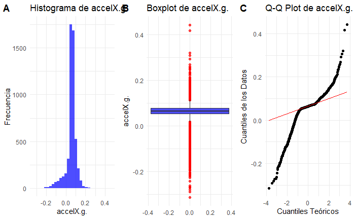

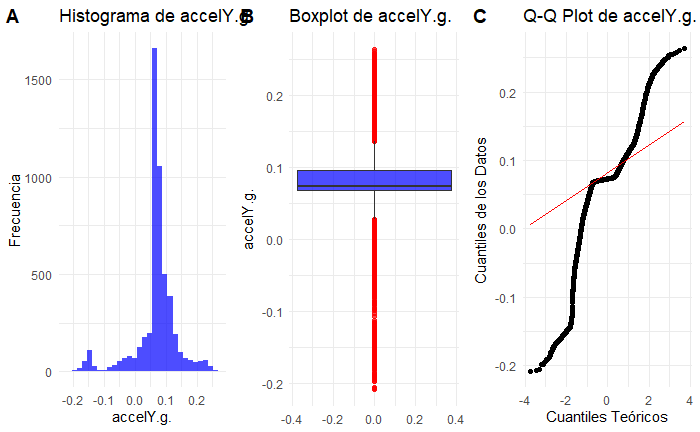

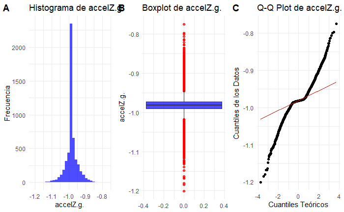

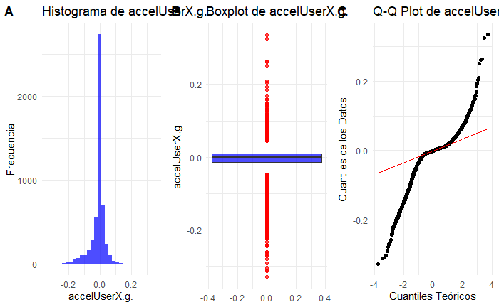

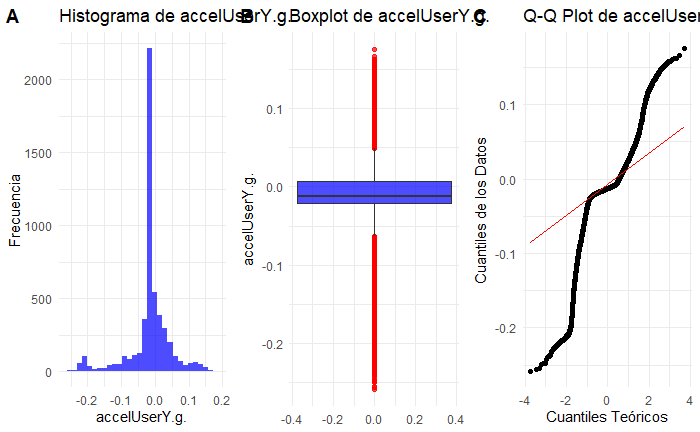

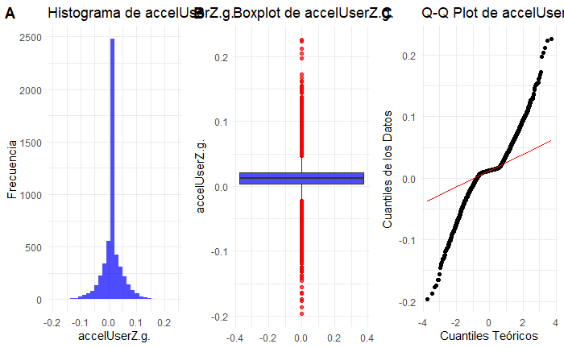

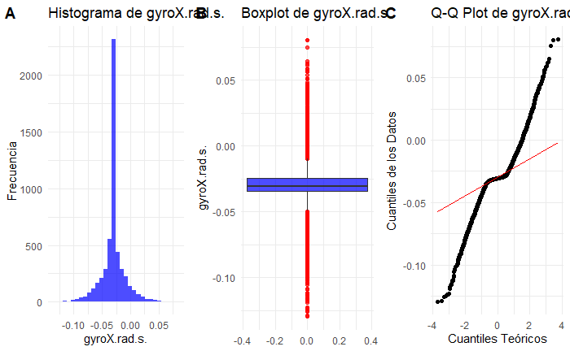

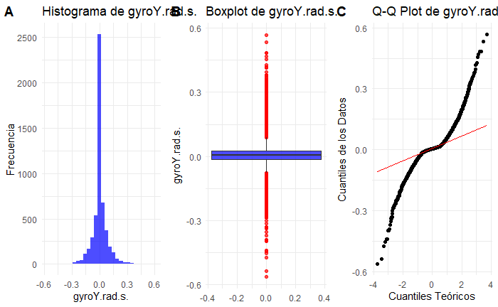

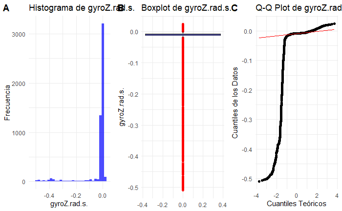

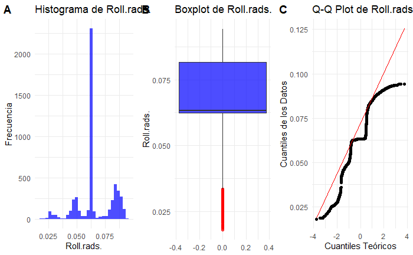

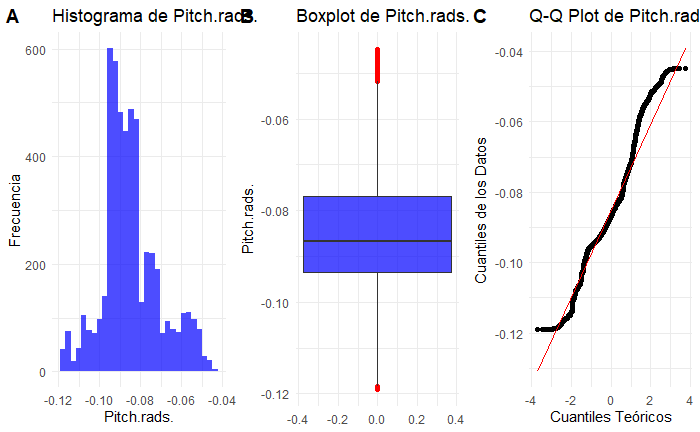

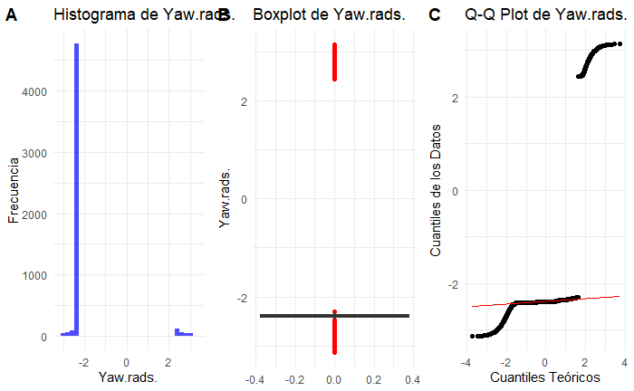

[21 more figures not shown]

```r
# Cargar librerías necesarias
if (!requireNamespace("tidyverse", quietly = TRUE)) install.packages("tidyverse")
if (!requireNamespace("cowplot", quietly = TRUE)) install.packages("cowplot")
library(tidyverse)
library(cowplot)

# Eliminar valores NA en num_data
num_data_clean <- num_data %>% drop_na()

# Confirmar que hay variables numéricas
if (ncol(num_data_clean) > 0) {
  # Iterar sobre las variables numéricas
  for (var in names(num_data_clean)) {
    # Crear histogramas
    hist_plot <- ggplot(num_data_clean, aes(x = !!sym(var))) +
      geom_histogram(bins = 30, fill = "blue", alpha = 0.7) +
      theme_minimal() +
      labs(title = paste("Histograma de", var), x = var, y = "Frecuencia")

    # Crear boxplots
    box_plot <- ggplot(num_data_clean, aes(y = !!sym(var))) +
      geom_boxplot(fill = "blue", alpha = 0.7, outlier.color = "red") +
      theme_minimal() +
      labs(title = paste("Boxplot de", var), y = var)

    # Crear Q-Q plots
    qq_plot <- ggplot(num_data_clean, aes(sample = !!sym(var))) +
      stat_qq() +
      stat_qq_line(color = "red") +
      theme_minimal() +
      labs(title = paste("Q-Q Plot de", var), x = "Cuantiles Teóricos", y = "Cuantiles de los Datos")

    # Mostrar los gráficos en una cuadrícula
    print(plot_grid(hist_plot, box_plot, qq_plot, ncol = 3, labels = c("A", "B", "C")))
  }
} else {
  cat("No hay variables numéricas en el dataset.\n")
}
```

```r
NA
NA
```

## 3.2 Variables Categóricas

Las variables categóricas se analizan para evaluar el balance de las clases, especialmente la variable objetivo.

```r
# Convertir las columnas character restantes en factor
data <- data %>%
  mutate(across(where(is.character), as.factor))

# Seleccionar las variables categóricas
cat_data <- data %>% select(where(is.factor))

# Verificar las estadísticas de variables categóricas
if (ncol(cat_data) > 0) {
  cat("### Estadísticas para Variables Categóricas\n")
  print(sapply(cat_data, table))
}
```

```
### Estadísticas para Variables Categóricas
$ActivityType

Coche Urbano 100
            5261

$ActivityConfidence

High  Low
4844  417
```

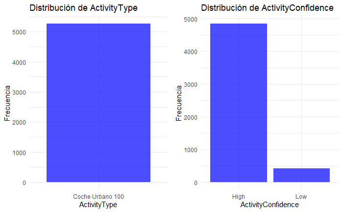

```r
# Gráficos de barras para cada variable categórica
# Crear una lista para almacenar los gráficos
plot_list <- list()

# Crear gráficos de barras para cada variable categórica y almacenarlos en la lista
for (var in names(cat_data)) {
  p <- ggplot(cat_data, aes_string(x = var)) +
    geom_bar(fill = "blue", alpha = 0.7) +
    theme_minimal() +
    labs(title = paste("Distribución de", var),
         x = var,
         y = "Frecuencia") +
    theme(axis.text.x = element_text(angle = 0, hjust = 0.5)) # Categorías horizontales

  # Agregar el gráfico a la lista
  plot_list[[var]] <- p
}
# Combinar todos los gráficos en una sola hoja
grid.arrange(grobs = plot_list, ncol = 2) # Ajusta ncol para cambiar las columnas
```

# 4. Análisis de Valores Faltantes y Outliers

## 4.1 Detección de Valores faltantes

Identificar valores faltantes es crucial porque pueden afectar el rendimiento del modelo predictivo. Este paso ayuda a decidir estrategias para imputar o manejar estos valores.

```r
cat("### Análisis de Valores Faltantes\n")
```

```
### Análisis de Valores Faltantes
```

```r
# Resumen de valores faltantes por columna
print(sapply(data, function(x) sum(is.na(x))))
```

```
               accelX.g.                accelY.g.                accelZ.g.            accelUserX.g.            accelUserY.g.            accelUserZ.g.             gyroX.rad.s.             gyroY.rad.s.
                       0                        0                        0                        0                        0                        0                        0                        0
            gyroZ.rad.s.               Roll.rads.              Pitch.rads.                Yaw.rads.                      m11                      m12                      m13                      m21
                       0                        0                        0                        0                        0                        0                        0                        0
                     m22                      m23                      m31                      m32                      m33                       qX                       qY                       qZ
                       0                        0                        0                        0                        0                        0                        0                        0
                      qW             ActivityType       ActivityConfidence    Pressure.kilopascals. RelativeAltitude.meters.                magX.뜻T.                magY.뜻T.                magZ.뜻T.
                       0                        0                        0                        0                        0                        0                        0                        0
            calMagX.뜻T.             calMagY.뜻T.             calMagZ.뜻T.
                       0                        0                        0
```

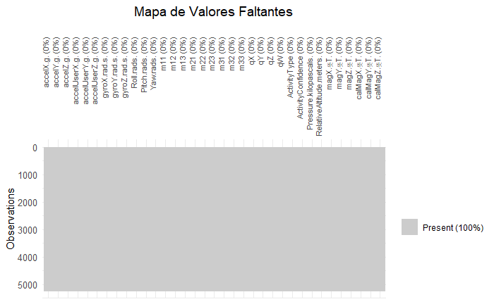

```r
# Visualización de valores faltantes mejorada
vis_miss(data) +
  ggtitle("Mapa de Valores Faltantes") +
  theme_minimal() +
  theme(
    axis.text.x = element_text(angle = 90, hjust = 1, size = 8), # Ajuste de las etiquetas del eje X
    axis.text.y = element_text(size = 10),                       # Ajuste de las etiquetas del eje Y
    plot.title = element_text(hjust = 0.5, size = 14)            # Centrar y ajustar tamaño del título
  )
```

```r
NA
NA
```

El resultado muestra que no hay datos nulos en el dataset.

## 4.2 Detección de Outliers Univariantes

Usaremos el rango intercuartílico (IQR) para identificar outliers y calcular el porcentaje de valores extremos en cada variable numérica.

```r
if (ncol(num_data) > 0) {
  cat("### Análisis de Outliers\n")

  # Cálculo de outliers por IQR
  outlier_detection <- num_data %>%
    summarise(across(everything(), ~ {
      q1 <- quantile(.x, 0.25, na.rm = TRUE)
      q3 <- quantile(.x, 0.75, na.rm = TRUE)
      iqr <- q3 - q1
      sum(.x < (q1 - 1.5 * iqr) | .x > (q3 + 1.5 * iqr), na.rm = TRUE) / length(.x) * 100
    }))

  # Transponer la tabla
  outlier_detection <- as.data.frame(t(outlier_detection))
  outlier_detection$Variable <- rownames(outlier_detection)
  rownames(outlier_detection) <- NULL

  # Reordenar las columnas
  outlier_detection <- outlier_detection %>%
    select(Variable, `Outliers (%)` = V1) %>%
    arrange(desc(`Outliers (%)`))  # Ordenar de mayor a menor

  # Mostrar la tabla
  print(outlier_detection)
}
```

```
### Análisis de Outliers
```

| Variable | Outliers (%) |
| --- | --- |
| gyroX.rad.s. | 23.664703 |
| accelZ.g. | 22.486219 |
| accelUserZ.g. | 22.448204 |
| gyroZ.rad.s. | 22.353165 |
| accelY.g. | 21.744915 |
| accelX.g. | 21.098650 |
| accelUserY.g. | 20.775518 |
| calMagY.뜻T. | 20.547424 |
| gyroY.rad.s. | 20.338339 |
| accelUserX.g. | 18.247481 |

[output cut: 23 more lines]

**Visualización de Outliers**

Utilizaremos boxplots para visualizar los outliers en cada variable numérica.

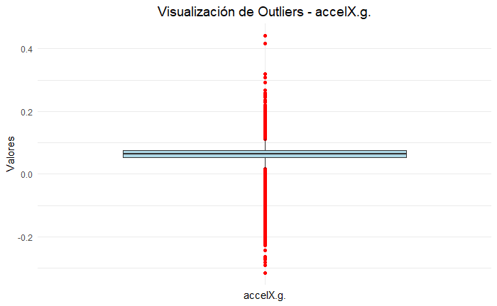

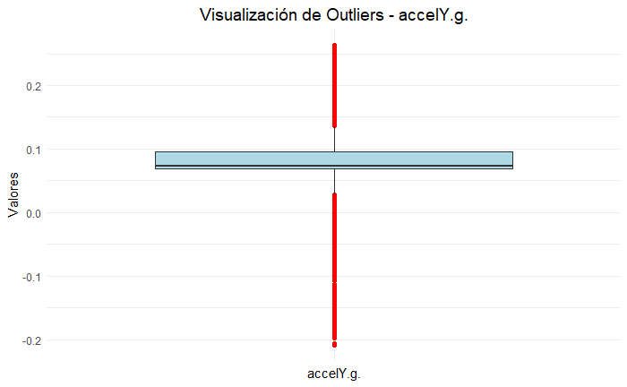

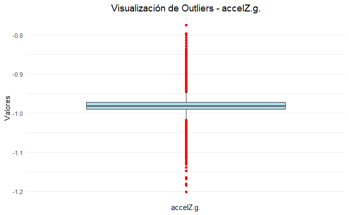

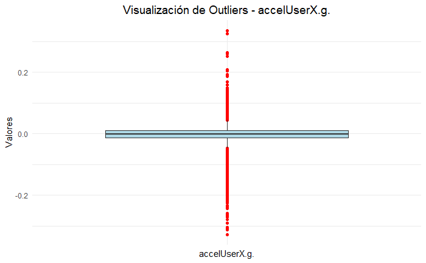

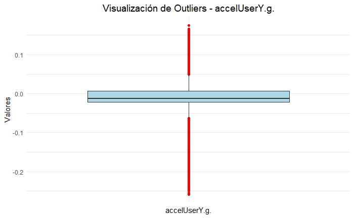

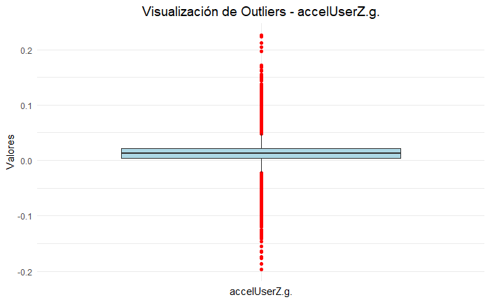

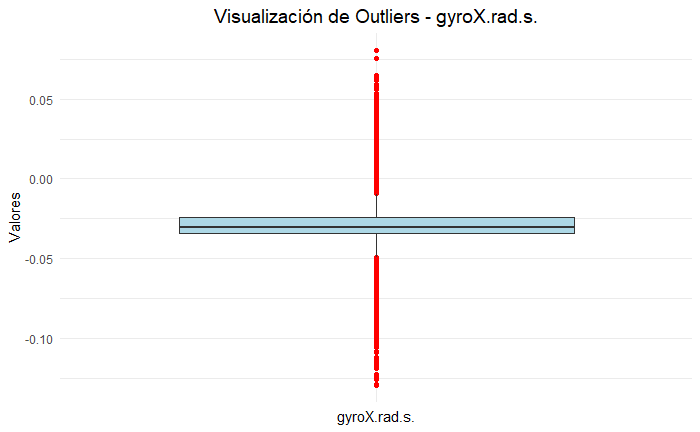

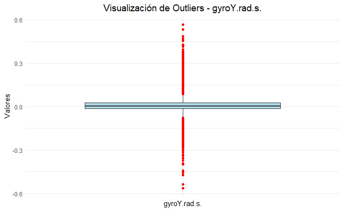

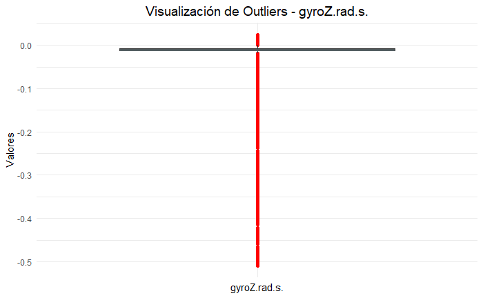

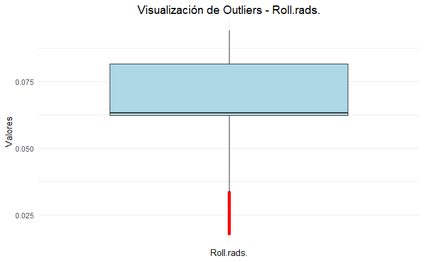

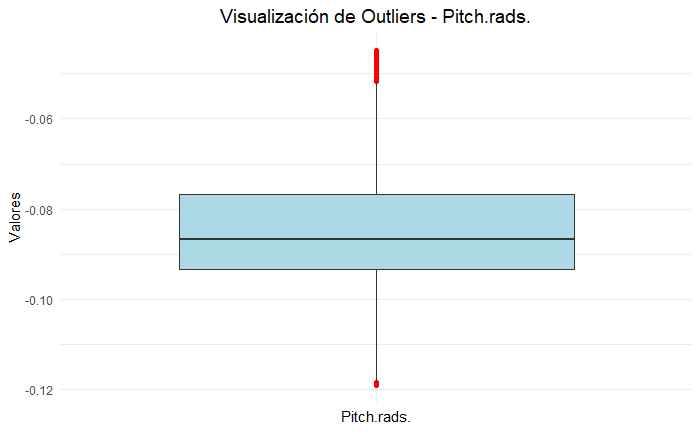

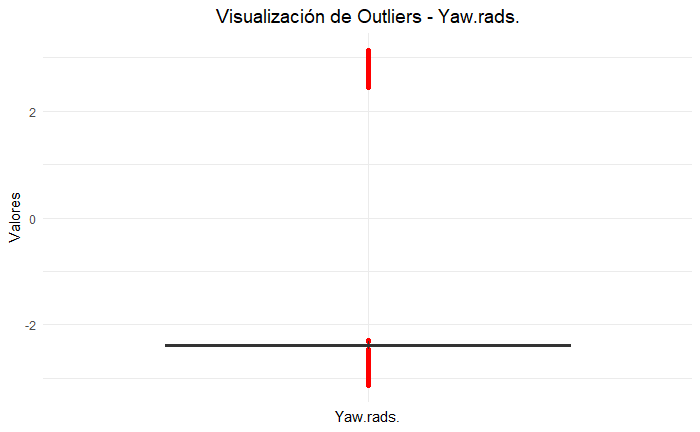

[21 more figures not shown]

```r
if (ncol(num_data) > 0) {
  # Transformar datos a formato largo
  num_data_long <- num_data %>%
    pivot_longer(cols = everything(), names_to = "Variable", values_to = "Valor")

  # Obtener las variables únicas
  unique_variables <- unique(num_data_long$Variable)

  # Crear gráficos individuales en un bucle
  for (var in unique_variables) {
    plot <- ggplot(num_data_long %>% filter(Variable == var), aes(x = Variable, y = Valor)) +
      geom_boxplot(outlier.colour = "red", outlier.size = 1.5, fill = "lightblue") +
      theme_minimal() +
      labs(
        title = paste("Visualización de Outliers -", var),
        x = var,
        y = "Valores"
      ) +
      theme(
        plot.title = element_text(size = 14, hjust = 0.5),
        axis.text.x = element_blank(),
        axis.ticks.x = element_blank()
      )

    # Usar print() explícito para mostrar cada gráfico
    print(plot)
  }
} else {
  cat("No hay variables numéricas en el dataset.\n")
}
```

```r
NA
NA
```

En el análisis univariado, se identificaron variables con un porcentaje significativo de outliers (>10%), lo que puede tener un impacto considerable en el análisis y los resultados si no se abordan adecuadamente. Las variables más relevantes son:

- **gyroX.rad.s. (23.66%) y accelZ.g. (22.48%)**
- **accelUserZ.g. (22,44%) y gyroZ.rad.s. (22,35)**

Estas variables son esenciales para comprender el sistema de transporte, incluyendo aspectos como posición, estabilidad, y precisión de los sensores. La aplicación de transformaciones adecuadas garantizará una mejor calidad de los datos y robustez en el análisis.

## 4.3 Multivariate Outliers

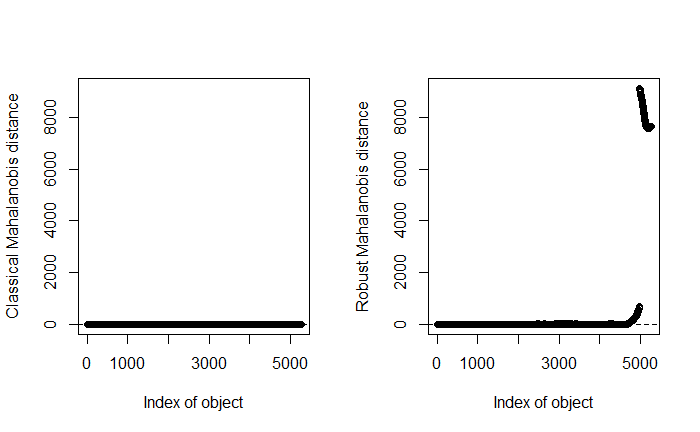

```r
# Cargar la librería
# Crear una copia del dataset original para trabajar
data_analysis <- data

# Seleccionar las variables continuas con mayor porcentaje de outliers (>10%), excluyendo las mencionadas
selected_vars <- data_analysis %>%
  select(gyroZ.rad.s., gyroY.rad.s., Yaw.rads., qZ, accelUserX.g.)  # Incluir variables relevantes

# Calcular las distancias de Mahalanobis (clásica y robusta)
res.out <- Moutlier(selected_vars, quantile = 0.9999)
```

```r
# Inspeccionar resultados
str(res.out)
```

```
List of 3
 $ md    : num [1:5261] 0.963 1.049 1.004 0.982 1.082 ...
 $ rd    : num [1:5261] 3.03 3.61 3.01 3.6 3.51 ...
 $ cutoff: num 5.07
```

```r
# Visualizar outliers multivariantes
par(mfrow = c(1, 1)) # Una sola ventana de gráfico
plot(res.out$md, res.out$rd,
     xlab = "Mahalanobis Clásica",
     ylab = "Mahalanobis Robusta",
     main = "Outliers Multivariantes con Distancias de Mahalanobis")
abline(h = res.out$cutoff, col = "red") # Umbral robusto
```

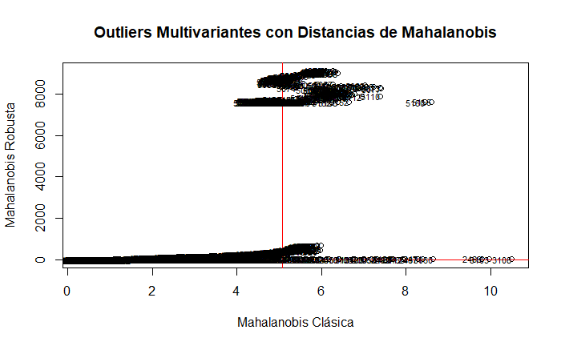

```r
abline(v = res.out$cutoff, col = "red") # Umbral clásico
text(res.out$md, res.out$rd, labels = rownames(data_analysis), adj = 1, cex = 0.7)
```

```r
# Identificar observaciones que son outliers multivariantes
outlier_indices <- which((res.out$md > res.out$cutoff) & (res.out$rd > res.out$cutoff))
cat("Observaciones outliers multivariantes:\n")
```

```
Observaciones outliers multivariantes:
```

```r
print(outlier_indices)
```

```
  [1] 2465 2467 2469 2471 2473 2487 2489 2491 2640 2925 3025 3051 3052 3055 3056 3058 3060 3062 3064 3101 3103 3104 3105 3106 3107 3108 3110 3112 3113 3123 3127 3129 3131 3133 3392 3396 3398 3400 4310 4312 4719 4886 4888
 [44] 4890 4908 4909 4910 4911 4912 4913 4914 4915 4916 4917 4918 4919 4920 4921 4922 4923 4924 4925 4926 4927 4928 4929 4930 4931 4932 4933 4934 4935 4936 4937 4938 4939 4940 4941 4942 4943 4944 4945 4946 4947 4948 4949
 [87] 4950 4951 4952 4953 4954 4955 4956 4957 4958 4959 4960 4961 4962 4963 4964 4965 4966 4967 4968 4969 4970 4971 4972 4973 4974 4975 4976 4977 4978 4979 4980 4981 4982 4983 4984 4985 4986 4987 4988 4989 4990 4991 4992
[130] 4993 4994 4995 4996 4997 4998 4999 5000 5001 5002 5003 5004 5005 5006 5007 5008 5009 5010 5011 5012 5013 5014 5015 5016 5017 5018 5019 5020 5021 5022 5023 5024 5025 5026 5027 5028 5029 5030 5031 5032 5033 5034 5035
[173] 5037 5039 5040 5046 5047 5048 5050 5053 5054 5056 5057 5058 5059 5060 5061 5062 5063 5064 5065 5066 5067 5068 5069 5070 5071 5072 5073 5074 5075 5076 5077 5078 5079 5080 5081 5082 5083 5084 5085 5086 5087 5088 5089
[216] 5090 5091 5092 5093 5094 5095 5096 5097 5098 5099 5100 5101 5102 5103 5104 5105 5106 5107 5108 5109 5110 5111 5112 5113 5114 5115 5116 5117 5118 5119 5120 5121 5122 5123 5124 5125 5126 5127 5128 5131 5139 5148 5151
[259] 5152 5154 5156 5158 5160 5162 5163 5164 5181 5187 5215 5217 5219 5220 5221 5222 5223 5224 5225 5226 5227 5228 5229 5230 5231 5232 5233 5234 5235 5236 5237 5238 5239 5240 5241 5242 5243 5244 5245 5246 5247 5248 5249
[302] 5250 5251 5252 5253 5254 5255 5256 5257 5258 5259 5260 5261
```

```r
# Crear un nuevo dataset con la columna de outliers sin afectar el original
data_with_outliers <- data_analysis %>%
  mutate(outlier_multivar = ifelse(row_number() %in% outlier_indices, "Outlier", "No Outlier"))

# Resumen de la nueva variable en el dataset modificado
table(data_with_outliers$outlier_multivar)
```

```
No Outlier    Outlier
      4948        313
```

Para visualizar estos outliers, se generó un gráfico bivariado que muestra las distancias clásicas frente a las robustas. Los puntos fuera de las líneas rojas en el gráfico representan las observaciones más atípicas, las cuales merecen un análisis más detallado.

```r
# Mostrar un resumen de las filas marcadas como outliers
summary(data_with_outliers %>% filter(outlier_multivar == "Outlier"))
```

```
   accelX.g.          accelY.g.          accelZ.g.       accelUserX.g.      accelUserY.g.     accelUserZ.g.        gyroX.rad.s.       gyroY.rad.s.       gyroZ.rad.s.       Roll.rads.      Pitch.rads.
 Min.   :-0.31520   Min.   :-0.09050   Min.   :-1.1095   Min.   :-0.32880   Min.   :-0.1755   Min.   :-0.141700   Min.   :-0.11490   Min.   :-0.56370   Min.   :-0.5097   Min.   :0.0179   Min.   :-0.1190
 1st Qu.:-0.12100   1st Qu.: 0.01470   1st Qu.:-1.0129   1st Qu.:-0.15540   1st Qu.:-0.0897   1st Qu.:-0.017900   1st Qu.:-0.04000   1st Qu.:-0.03450   1st Qu.:-0.4351   1st Qu.:0.0262   1st Qu.:-0.1077
 Median :-0.06980   Median : 0.05500   Median :-0.9877   Median :-0.11320   Median :-0.0405   Median : 0.005700   Median :-0.02690   Median : 0.03180   Median :-0.3842   Median :0.0343   Median :-0.1033
 Mean   :-0.05846   Mean   : 0.04908   Mean   :-0.9888   Mean   :-0.09746   Mean   :-0.0509   Mean   : 0.005511   Mean   :-0.02828   Mean   : 0.03146   Mean   :-0.3042   Mean   :0.0393   Mean   :-0.1005
 3rd Qu.:-0.00420   3rd Qu.: 0.09320   3rd Qu.:-0.9622   3rd Qu.:-0.04370   3rd Qu.:-0.0126   3rd Qu.: 0.032000   3rd Qu.:-0.01670   3rd Qu.: 0.09070   3rd Qu.:-0.0665   3rd Qu.:0.0488   3rd Qu.:-0.0957
 Max.   : 0.44160   Max.   : 0.16410   Max.   :-0.8271   Max.   : 0.33520   Max.   : 0.0753   Max.   : 0.223500   Max.   : 0.05620   Max.   : 0.56730   Max.   : 0.0237   Max.   :0.0910   Max.   :-0.0578
   Yaw.rads.            m11               m12               m13               m21               m22               m23               m31                m32                m33               qX                qY
 Min.   :-3.1382   Min.   :-0.9989   Min.   :-0.7391   Min.   :-0.0905   Min.   :-0.6368   Min.   :-0.9951   Min.   :-0.1187   Min.   :-0.09930   Min.   :-0.12780   Min.   :0.9918   Min.   :0.00840   Min.   :0.03450
 1st Qu.:-2.3644   1st Qu.:-0.9869   1st Qu.:-0.1347   1st Qu.:-0.0486   1st Qu.:-0.5280   1st Qu.:-0.9829   1st Qu.:-0.1075   1st Qu.:-0.07830   1st Qu.:-0.10060   1st Qu.:0.9938   1st Qu.:0.02120   1st Qu.:0.04900
 Median : 2.4578   Median :-0.9211   Median : 0.1739   Median :-0.0341   Median :-0.1696   Median :-0.9170   Median :-0.1031   Median :-0.05120   Median :-0.09530   Median :0.9940   Median :0.02290   Median :0.04950
 Mean   : 0.7196   Mean   :-0.8825   Mean   : 0.1333   Mean   :-0.0391   Mean   :-0.1286   Mean   :-0.8789   Mean   :-0.1003   Mean   :-0.05306   Mean   :-0.09024   Mean   :0.9940   Mean   :0.02384   Mean   :0.04917
 3rd Qu.: 2.7643   3rd Qu.:-0.7720   3rd Qu.: 0.5331   3rd Qu.:-0.0260   3rd Qu.: 0.1389   3rd Qu.:-0.7691   3rd Qu.:-0.0955   3rd Qu.:-0.03580   3rd Qu.:-0.07640   3rd Qu.:0.9942   3rd Qu.:0.02710   3rd Qu.:0.04990
 Max.   : 3.1406   Max.   :-0.6684   Max.   : 0.6432   Max.   :-0.0177   Max.   : 0.7438   Max.   :-0.6636   Max.   :-0.0578   Max.   : 0.01660   Max.   :-0.06950   Max.   :0.9974   Max.   :0.03510   Max.   :0.05850
       qZ                qW                    ActivityType ActivityConfidence Pressure.kilopascals. RelativeAltitude.meters.   magX.뜻T.       magY.뜻T.       magZ.뜻T.       calMagX.뜻T.     calMagY.뜻T.
 Min.   :-0.9985   Min.   :-0.3411   Coche Urbano 100:313   High:313           Min.   :102.5         Min.   :36.03            Min.   :159.6   Min.   :51.64   Min.   :-617.9   Min.   :-23.53   Min.   :-14.569
 1st Qu.:-0.9955   1st Qu.:-0.2765                          Low :  0           1st Qu.:102.5         1st Qu.:36.28            1st Qu.:161.3   1st Qu.:54.46   1st Qu.:-616.9   1st Qu.:-21.98   1st Qu.:-11.711
 Median :-0.9788   Median :-0.0863                                             Median :102.5         Median :36.28            Median :162.5   Median :62.01   Median :-616.2   Median :-20.98   Median : -3.571
 Mean   :-0.9685   Mean   :-0.0671                                             Mean   :102.5         Mean   :36.41            Mean   :162.7   Mean   :63.33   Mean   :-615.8   Mean   :-20.43   Mean   : -2.906
 3rd Qu.:-0.9400   3rd Qu.: 0.0686                                             3rd Qu.:102.5         3rd Qu.:36.35            3rd Qu.:163.5   3rd Qu.:68.85   3rd Qu.:-614.8   3rd Qu.:-19.94   3rd Qu.:  2.893
 Max.   :-0.9118   Max.   : 0.4066                                             Max.   :102.5         Max.   :37.81            Max.   :170.5   Max.   :83.84   Max.   :-612.0   Max.   :-10.74   Max.   : 18.160
  calMagZ.뜻T.     outlier_multivar
 Min.   :-1.4598   Length:313
 1st Qu.:-0.5925   Class :character
 Median :-0.0102   Mode  :character
 Mean   : 0.2161
 3rd Qu.: 0.7045
 Max.   : 4.0421
```

Los resultados indicaron que **313 observaciones** fueron clasificadas como outliers multivariantes. Estas observaciones sobresalen significativamente en el espacio multivariante, lo que sugiere la presencia de eventos extremos o anomalías en los datos. Este comportamiento podría estar asociado a movimientos inusuales del sistema, errores en la captura de datos o condiciones específicas del entorno.

Para abordar estos resultados, se recomienda aplicar técnicas de **winsorización** para limitar el impacto de los valores extremos sin eliminar las observaciones, preservando así su relevancia potencial.

### Revision Manual

```r
# 1. Definir los índices de los outliers multivariantes (actualizados tras revisión manual)
outlier_indices <- c(1, 20, 39, 58, 77, 96, 115, 134, 153, 172, 191, 210, 229, 248, 267, 286, 305)

# 2. Filtrar las observaciones outliers del dataset original
outlier_data <- data_analysis[outlier_indices, ]
View(outlier_data)  # Abrir la vista interactiva para inspección

# 3. Resumen estadístico de los outliers
summary(outlier_data)
```

```
   accelX.g.         accelY.g.         accelZ.g.       accelUserX.g.        accelUserY.g.      accelUserZ.g.      gyroX.rad.s.       gyroY.rad.s.        gyroZ.rad.s.         Roll.rads.      Pitch.rads.
 Min.   :0.04950   Min.   :0.06100   Min.   :-0.9865   Min.   :-0.0156000   Min.   :-0.03480   Min.   :0.00340   Min.   :-0.03400   Min.   :-0.009600   Min.   :-0.010800   Min.   :0.0621   Min.   :-0.09570
 1st Qu.:0.05510   1st Qu.:0.06980   1st Qu.:-0.9845   1st Qu.:-0.0032000   1st Qu.:-0.02460   1st Qu.:0.01030   1st Qu.:-0.03120   1st Qu.:-0.001900   1st Qu.:-0.009000   1st Qu.:0.0624   1st Qu.:-0.09510
 Median :0.05830   Median :0.07220   Median :-0.9805   Median :-0.0014000   Median :-0.02320   Median :0.01230   Median :-0.03090   Median : 0.004800   Median :-0.008400   Median :0.0626   Median :-0.09440
 Mean   :0.06063   Mean   :0.07197   Mean   :-0.9813   Mean   :-0.0009706   Mean   :-0.02227   Mean   :0.01196   Mean   :-0.03044   Mean   : 0.006218   Mean   :-0.008182   Mean   :0.0625   Mean   :-0.09441
 3rd Qu.:0.06810   3rd Qu.:0.07330   3rd Qu.:-0.9797   3rd Qu.: 0.0044000   3rd Qu.:-0.01980   3rd Qu.:0.01450   3rd Qu.:-0.02990   3rd Qu.: 0.012200   3rd Qu.:-0.007200   3rd Qu.:0.0626   3rd Qu.:-0.09370
 Max.   :0.07700   Max.   :0.08420   Max.   :-0.9742   Max.   : 0.0101000   Max.   :-0.01130   Max.   :0.01670   Max.   :-0.02530   Max.   : 0.029700   Max.   :-0.005900   Max.   :0.0627   Max.   :-0.09300
   Yaw.rads.           m11               m12               m13                m21              m22               m23                m31               m32               m33               qX                qY
 Min.   :-2.421   Min.   :-0.7536   Min.   :-0.6678   Min.   :-0.06240   Min.   :0.6572   Min.   :-0.7477   Min.   :-0.09560   Min.   :0.01600   Min.   :-0.1127   Min.   :0.9935   Min.   :0.01190   Min.   :0.05460
 1st Qu.:-2.413   1st Qu.:-0.7488   1st Qu.:-0.6667   1st Qu.:-0.06230   1st Qu.:0.6626   1st Qu.:-0.7430   1st Qu.:-0.09500   1st Qu.:0.01620   1st Qu.:-0.1121   1st Qu.:0.9935   1st Qu.:0.01220   1st Qu.:0.05490
 Median :-2.405   Median :-0.7433   Median :-0.6661   Median :-0.06230   Median :0.6688   Median :-0.7375   Median :-0.09420   Median :0.01660   Median :-0.1118   Median :0.9936   Median :0.01220   Median :0.05530
 Mean   :-2.409   Mean   :-0.7456   Mean   :-0.6634   Mean   :-0.06218   Mean   :0.6661   Mean   :-0.7398   Mean   :-0.09429   Mean   :0.01655   Mean   :-0.1117   Mean   :0.9936   Mean   :0.01224   Mean   :0.05523
 3rd Qu.:-2.404   3rd Qu.:-0.7427   3rd Qu.:-0.6599   3rd Qu.:-0.06210   3rd Qu.:0.6694   3rd Qu.:-0.7370   3rd Qu.:-0.09360   3rd Qu.:0.01680   3rd Qu.:-0.1112   3rd Qu.:0.9937   3rd Qu.:0.01230   3rd Qu.:0.05550
 Max.   :-2.403   Max.   :-0.7417   Max.   :-0.6545   Max.   :-0.06170   Max.   :0.6705   Max.   :-0.7360   Max.   :-0.09290   Max.   :0.01730   Max.   :-0.1107   Max.   :0.9937   Max.   :0.01240   Max.   :0.05570
       qZ                qW                   ActivityType ActivityConfidence Pressure.kilopascals. RelativeAltitude.meters.   magX.뜻T.       magY.뜻T.       magZ.뜻T.       calMagX.뜻T.     calMagY.뜻T.
 Min.   :-0.9347   Min.   :0.3508   Coche Urbano 100:17    High:17            Min.   :102.5         Min.   :35.90            Min.   :164.6   Min.   :79.88   Min.   :-614.1   Min.   :-17.24   Min.   :13.97
 1st Qu.:-0.9335   1st Qu.:0.3542                          Low : 0            1st Qu.:102.5         1st Qu.:35.91            1st Qu.:165.3   1st Qu.:80.21   1st Qu.:-614.0   1st Qu.:-16.88   1st Qu.:14.29
 Median :-0.9320   Median :0.3581                                             Median :102.5         Median :35.91            Median :166.4   Median :80.34   Median :-613.8   Median :-16.45   Median :14.45
 Mean   :-0.9326   Mean   :0.3564                                             Mean   :102.5         Mean   :35.91            Mean   :166.2   Mean   :80.30   Mean   :-613.7   Mean   :-16.30   Mean   :14.39
 3rd Qu.:-0.9318   3rd Qu.:0.3585                                             3rd Qu.:102.5         3rd Qu.:35.91            3rd Qu.:167.0   3rd Qu.:80.46   3rd Qu.:-613.6   3rd Qu.:-15.56   3rd Qu.:14.52
 Max.   :-0.9316   Max.   :0.3592                                             Max.   :102.5         Max.   :35.91            Max.   :168.0   Max.   :80.63   Max.   :-613.2   Max.   :-15.39   Max.   :14.73
  calMagZ.뜻T.
 Min.   :1.886
 1st Qu.:2.120
 Median :2.204
 Mean   :2.180
 3rd Qu.:2.239
 Max.   :2.455
```

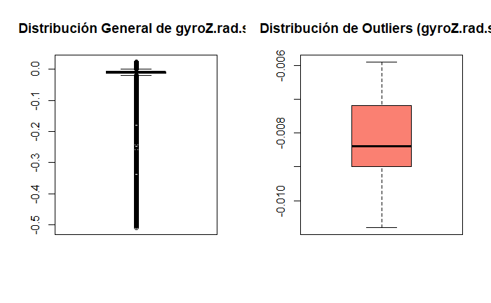

```r
# 4. Comparar distribuciones con el resto del dataset
# Variable gyroZ.rad.s.
par(mfrow = c(1, 2))  # Dividir la pantalla en dos gráficos
boxplot(data_analysis$gyroZ.rad.s., main = "Distribución General de gyroZ.rad.s.", col = "lightblue")
boxplot(outlier_data$gyroZ.rad.s., main = "Distribución de Outliers (gyroZ.rad.s.)", col = "salmon")
```

```r
# 5. Inspeccionar registros adicionales
head(outlier_data[, c("ActivityType", "gyroZ.rad.s.", "gyroY.rad.s.")])
```

|  | ActivityType | gyroZ.rad.s. | gyroY.rad.s. |
| --- | --- | --- | --- |
| 1 | Coche Urbano 100 | -0.0084 | 0.0027 |
| 20 | Coche Urbano 100 | -0.0070 | 0.0048 |
| 39 | Coche Urbano 100 | -0.0097 | 0.0048 |
| 58 | Coche Urbano 100 | -0.0072 | 0.0205 |
| 77 | Coche Urbano 100 | -0.0068 | 0.0083 |
| 96 | Coche Urbano 100 | -0.0084 | -0.0030 |

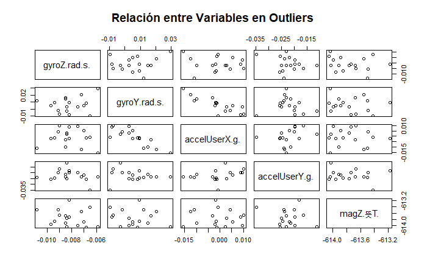

```r
# 6. Relación entre variables seleccionadas en los outliers
pairs(outlier_data[, c("gyroZ.rad.s.", "gyroY.rad.s.", "accelUserX.g.", "accelUserY.g.", "magZ.뜻T.")],
      main = "Relación entre Variables en Outliers")
```

```r
# 7. Agregar una columna de decisión manual para cada outlier
outlier_data <- outlier_data %>%
  mutate(decision = ifelse(gyroZ.rad.s. > 15 & gyroY.rad.s. > 15, "Conservar", "Revisar"))

# Mostrar dataset con decisiones
View(outlier_data)

# 8. Incorporar las decisiones al dataset original
data_analysis$outlier_review <- "No Outlier"
data_analysis$outlier_review[outlier_indices] <- outlier_data$decision

# 9. Resumen de las decisiones tomadas
table(data_analysis$outlier_review)
```

```
No Outlier    Revisar
      5244         17
```

### Validación Manual de Outliers Multivariantes

#### Observaciones de la Validación Manual

**Verificación de los Valores:**

**Análisis de Contexto:**

- Estas mediciones pueden reflejar eventos reales, como cambios de ritmo, movimientos bruscos o variaciones en el terreno, aunque no se descartan posibles ruidos del sensor.

### Conclusión de la Validación Manual

- No se detectaron errores evidentes en el formato de los datos ni inconsistencias generales en los registros revisados.

**Hipótesis:**

- **Nula (H₀):** Los datos tienen una distribución normal.
- **Alternativa (H₁):** Los datos no tienen una distribución normal.

```r
# Filtrar variables numéricas excluyendo las indicadas
variables_a_descartar <- c("Lat", "Long", "Speed.m.s.", "TrueHeading",
                           "Alt.m.", "HorizontalAccuracy.m.", "VerticalAccuracy.m.", "Course")

num_data_filtrado <- num_data[, !(names(num_data) %in% variables_a_descartar)]

# Filtrar solo las columnas numéricas que tengan entre 3 y 5000 valores no NA
num_data_filtrado <- num_data_filtrado[, sapply(num_data_filtrado, function(x) {
  num_vals <- sum(!is.na(x))  # Contar valores no nulos
  num_vals >= 3 && num_vals <= 5000
})]

# Verificar si hay variables numéricas restantes después del filtrado
if (ncol(num_data_filtrado) > 0) {
  cat("### Pruebas de Normalidad con Interpretación\n")

  # Crear una lista para almacenar resultados
  normality_interpretation <- list()

  # Iterar por cada columna numérica
  for (variable in names(num_data_filtrado)) {
    # Realizar el test de Shapiro-Wilk
    shapiro_test <- shapiro.test(num_data_filtrado[[variable]])

    # Evaluar el resultado
    if (shapiro_test$p.value > 0.05) {
      interpretation <- paste(
        "La variable", variable,
        "tiene un p-value =", round(shapiro_test$p.value, 4),
        "- Se acepta la hipótesis nula, la muestra tiene una distribución normal (Probablemente Gaussiana).\n"
      )
    } else {
      interpretation <- paste(
        "La variable", variable,
        "tiene un p-value =", round(shapiro_test$p.value, 4),
        "- Se rechaza la hipótesis nula, la muestra no tiene una distribución normal (Probablemente no Gaussiana).\n"
      )
    }

    # Agregar resultado a la lista
    normality_interpretation[[variable]] <- interpretation
  }

  # Imprimir resultados para cada variable
  for (result in normality_interpretation) {
    cat(result)
    cat("------------------------------------------------------------\n")
  }
} else {
  cat("No hay variables numéricas en el dataset después de filtrar.\n")
}
```

```
No hay variables numéricas en el dataset después de filtrar.
```

# 6. Análisis de Correlaciones

Las correlaciones entre variables numéricas son esenciales para identificar redundancias o relaciones útiles para el modelado.

```r
install.packages("kableExtra")
```

```
Error in install.packages : Updating loaded packages
```

```r
library(knitr)      # Para formatear tablas
library(kableExtra) # Para mejorar la presentación

# Seleccionar solo variables numéricas relevantes, excluyendo las mencionadas
num_data_filtered <- num_data

# Calcular la matriz de correlación
cor_matrix <- cor(num_data_filtered, use = "complete.obs")

# Redondear para mejor visualización
cor_matrix_rounded <- round(cor_matrix, 2)

# Imprimir la matriz de correlación en la consola
print(cor_matrix_rounded)
```

```
                         accelX.g. accelY.g. accelZ.g. accelUserX.g. accelUserY.g. accelUserZ.g. gyroX.rad.s. gyroY.rad.s. gyroZ.rad.s. Roll.rads. Pitch.rads. Yaw.rads.   m11   m12   m13   m21   m22   m23   m31   m32
accelX.g.                     1.00      0.14      0.11          0.90          0.19          0.08        -0.13        -0.26         0.76       0.59        0.20     -0.50  0.68 -0.57 -0.59  0.57  0.69  0.20  0.42 -0.34
accelY.g.                     0.14      1.00      0.11          0.03          0.97          0.11         0.05        -0.10         0.05       0.40       -0.48     -0.12  0.09 -0.10 -0.40  0.10  0.11 -0.48  0.14 -0.59
accelZ.g.                     0.11      0.11      1.00          0.10          0.07          0.92         0.04        -0.36         0.03       0.11       -0.06     -0.03  0.04 -0.03 -0.11  0.03  0.04 -0.06  0.01 -0.12
accelUserX.g.                 0.90      0.03      0.10          1.00          0.09          0.09        -0.14        -0.38         0.71       0.35        0.24     -0.40  0.64 -0.47 -0.35  0.47  0.64  0.24  0.37 -0.12
accelUserY.g.                 0.19      0.97      0.07          0.09          1.00          0.09         0.03        -0.09         0.14       0.43       -0.30     -0.23  0.18 -0.22 -0.43  0.22  0.19 -0.30  0.22 -0.53
accelUserZ.g.                 0.08      0.11      0.92          0.09          0.09          1.00        -0.02        -0.47         0.03       0.08       -0.03     -0.04  0.04 -0.04 -0.08  0.04  0.04 -0.03  0.02 -0.08
gyroX.rad.s.                 -0.13      0.05      0.04         -0.14          0.03         -0.02         1.00         0.05        -0.09      -0.02       -0.06      0.01 -0.09  0.03  0.02 -0.03 -0.09 -0.06 -0.01 -0.03
gyroY.rad.s.                 -0.26     -0.10     -0.36         -0.38         -0.09         -0.47         0.05         1.00        -0.08      -0.03       -0.03      0.06 -0.08  0.08  0.03 -0.08 -0.08 -0.03 -0.08  0.02
gyroZ.rad.s.                  0.76      0.05      0.03          0.71          0.14          0.03        -0.09        -0.08         1.00       0.51        0.34     -0.60  0.90 -0.71 -0.51  0.71  0.90  0.34  0.61 -0.21
Roll.rads.                    0.59      0.40      0.11          0.35          0.43          0.08        -0.02        -0.03         0.51       1.00       -0.04     -0.54  0.45 -0.60 -1.00  0.60  0.47 -0.04  0.36 -0.83
Pitch.rads.                   0.20     -0.48     -0.06          0.24         -0.30         -0.03        -0.06        -0.03         0.34      -0.04        1.00     -0.42  0.36 -0.49  0.03  0.48  0.34  1.00  0.29  0.52
Yaw.rads.                    -0.50     -0.12     -0.03         -0.40         -0.23         -0.04         0.01         0.06        -0.60      -0.54       -0.42      1.00 -0.45  0.91  0.54 -0.91 -0.45 -0.42 -0.84  0.35
m11                           0.68      0.09      0.04          0.64          0.18          0.04        -0.09        -0.08         0.90       0.45        0.36     -0.45  1.00 -0.61 -0.46  0.61  1.00  0.36  0.49 -0.12
m12                          -0.57     -0.10     -0.03         -0.47         -0.22         -0.04         0.03         0.08        -0.71      -0.60       -0.49      0.91 -0.61  1.00  0.60 -1.00 -0.61 -0.49 -0.91  0.37
m13                          -0.59     -0.40     -0.11         -0.35         -0.43         -0.08         0.02         0.03        -0.51      -1.00        0.03      0.54 -0.46  0.60  1.00 -0.60 -0.47  0.03 -0.36  0.83
m21                           0.57      0.10      0.03          0.47          0.22          0.04        -0.03        -0.08         0.71       0.60        0.48     -0.91  0.61 -1.00 -0.60  1.00  0.61  0.48  0.91 -0.37
m22                           0.69      0.11      0.04          0.64          0.19          0.04        -0.09        -0.08         0.90       0.47        0.34     -0.45  1.00 -0.61 -0.47  0.61  1.00  0.34  0.49 -0.15
m23                           0.20     -0.48     -0.06          0.24         -0.30         -0.03        -0.06        -0.03         0.34      -0.04        1.00     -0.42  0.36 -0.49  0.03  0.48  0.34  1.00  0.28  0.52
m31                           0.42      0.14      0.01          0.37          0.22          0.02        -0.01        -0.08         0.61       0.36        0.29     -0.84  0.49 -0.91 -0.36  0.91  0.49  0.28  1.00 -0.33
m32                          -0.34     -0.59     -0.12         -0.12         -0.53         -0.08        -0.03         0.02        -0.21      -0.83        0.52      0.35 -0.12  0.37  0.83 -0.37 -0.15  0.52 -0.33  1.00
m33                          -0.18     -0.59     -0.12          0.00         -0.47         -0.07        -0.03        -0.01         0.00      -0.62        0.79     -0.09  0.02 -0.10  0.61  0.10  0.00  0.79  0.12  0.86
qX                            0.04      0.15      0.07         -0.09          0.10          0.03        -0.01         0.05        -0.20       0.39       -0.29      0.43 -0.11  0.45 -0.39 -0.45 -0.11 -0.29 -0.72 -0.27
qY                            0.17      0.63      0.11          0.01          0.50          0.07         0.04         0.00         0.04       0.58       -0.82     -0.04 -0.01 -0.03 -0.58  0.04  0.01 -0.82  0.11 -0.91
qZ                            0.69      0.11      0.05          0.64          0.20          0.05        -0.09        -0.08         0.90       0.47        0.35     -0.45  1.00 -0.61 -0.47  0.61  1.00  0.34  0.49 -0.15
qW                            0.57      0.10      0.03          0.47          0.22          0.04        -0.03        -0.08         0.72       0.60        0.49     -0.90  0.62 -1.00 -0.60  1.00  0.62  0.49  0.91 -0.37
```

[output cut: 37 more lines]

```r
# Alternativamente, generar una tabla con kable si prefieres una salida más ordenada
library(knitr)
kable(cor_matrix_rounded, caption = "Tabla de Correlaciones (Excluyendo Variables No Relevantes)")
```

Tabla de Correlaciones (Excluyendo Variables No Relevantes)

|  | accelX.g. | accelY.g. | accelZ.g. | accelUserX.g. | accelUserY.g. | accelUserZ.g. | gyroX.rad.s. | gyroY.rad.s. | gyroZ.rad.s. | Roll.rads. | Pitch.rads. | Yaw.rads. | m11 | m12 | m13 | m21 | m22 | m23 | m31 | m32 | m33 | qX | qY | qZ | qW | Pressure.kilopascals. | RelativeAltitude.meters. | magX.뜻T. | magY.뜻T. | … |
| --- | --- | --- | --- | --- | --- | --- | --- | --- | --- | --- | --- | --- | --- | --- | --- | --- | --- | --- | --- | --- | --- | --- | --- | --- | --- | --- | --- | --- | --- | --- |
| accelX.g. | 1.00 | 0.14 | 0.11 | 0.90 | 0.19 | 0.08 | -0.13 | -0.26 | 0.76 | 0.59 | 0.20 | -0.50 | 0.68 | -0.57 | -0.59 | 0.57 | 0.69 | 0.20 | 0.42 | -0.34 | -0.18 | 0.04 | 0.17 | 0.69 | 0.57 | -0.18 | 0.18 | 0.42 | 0.56 | … |
| accelY.g. | 0.14 | 1.00 | 0.11 | 0.03 | 0.97 | 0.11 | 0.05 | -0.10 | 0.05 | 0.40 | -0.48 | -0.12 | 0.09 | -0.10 | -0.40 | 0.10 | 0.11 | -0.48 | 0.14 | -0.59 | -0.59 | 0.15 | 0.63 | 0.11 | 0.10 | -0.36 | 0.36 | 0.13 | 0.08 | … |
| accelZ.g. | 0.11 | 0.11 | 1.00 | 0.10 | 0.07 | 0.92 | 0.04 | -0.36 | 0.03 | 0.11 | -0.06 | -0.03 | 0.04 | -0.03 | -0.11 | 0.03 | 0.04 | -0.06 | 0.01 | -0.12 | -0.12 | 0.07 | 0.11 | 0.05 | 0.03 | -0.08 | 0.08 | 0.04 | 0.03 | … |
| accelUserX.g. | 0.90 | 0.03 | 0.10 | 1.00 | 0.09 | 0.09 | -0.14 | -0.38 | 0.71 | 0.35 | 0.24 | -0.40 | 0.64 | -0.47 | -0.35 | 0.47 | 0.64 | 0.24 | 0.37 | -0.12 | 0.00 | -0.09 | 0.01 | 0.64 | 0.47 | -0.04 | 0.04 | 0.37 | 0.46 | … |
| accelUserY.g. | 0.19 | 0.97 | 0.07 | 0.09 | 1.00 | 0.09 | 0.03 | -0.09 | 0.14 | 0.43 | -0.30 | -0.23 | 0.18 | -0.22 | -0.43 | 0.22 | 0.19 | -0.30 | 0.22 | -0.53 | -0.47 | 0.10 | 0.50 | 0.20 | 0.22 | -0.43 | 0.43 | 0.18 | 0.20 | … |
| accelUserZ.g. | 0.08 | 0.11 | 0.92 | 0.09 | 0.09 | 1.00 | -0.02 | -0.47 | 0.03 | 0.08 | -0.03 | -0.04 | 0.04 | -0.04 | -0.08 | 0.04 | 0.04 | -0.03 | 0.02 | -0.08 | -0.07 | 0.03 | 0.07 | 0.05 | 0.04 | -0.07 | 0.07 | 0.04 | 0.04 | … |
| gyroX.rad.s. | -0.13 | 0.05 | 0.04 | -0.14 | 0.03 | -0.02 | 1.00 | 0.05 | -0.09 | -0.02 | -0.06 | 0.01 | -0.09 | 0.03 | 0.02 | -0.03 | -0.09 | -0.06 | -0.01 | -0.03 | -0.03 | -0.01 | 0.04 | -0.09 | -0.03 | 0.01 | -0.01 | -0.01 | -0.05 | … |
| gyroY.rad.s. | -0.26 | -0.10 | -0.36 | -0.38 | -0.09 | -0.47 | 0.05 | 1.00 | -0.08 | -0.03 | -0.03 | 0.06 | -0.08 | 0.08 | 0.03 | -0.08 | -0.08 | -0.03 | -0.08 | 0.02 | -0.01 | 0.05 | 0.00 | -0.08 | -0.08 | -0.01 | 0.01 | -0.05 | -0.07 | … |
| gyroZ.rad.s. | 0.76 | 0.05 | 0.03 | 0.71 | 0.14 | 0.03 | -0.09 | -0.08 | 1.00 | 0.51 | 0.34 | -0.60 | 0.90 | -0.71 | -0.51 | 0.71 | 0.90 | 0.34 | 0.61 | -0.21 | 0.00 | -0.20 | 0.04 | 0.90 | 0.72 | -0.07 | 0.07 | 0.55 | 0.70 | … |
| Roll.rads. | 0.59 | 0.40 | 0.11 | 0.35 | 0.43 | 0.08 | -0.02 | -0.03 | 0.51 | 1.00 | -0.04 | -0.54 | 0.45 | -0.60 | -1.00 | 0.60 | 0.47 | -0.04 | 0.36 | -0.83 | -0.62 | 0.39 | 0.58 | 0.47 | 0.60 | -0.51 | 0.51 | 0.35 | 0.58 | … |
| Pitch.rads. | 0.20 | -0.48 | -0.06 | 0.24 | -0.30 | -0.03 | -0.06 | -0.03 | 0.34 | -0.04 | 1.00 | -0.42 | 0.36 | -0.49 | 0.03 | 0.48 | 0.34 | 1.00 | 0.29 | 0.52 | 0.79 | -0.29 | -0.82 | 0.35 | 0.49 | -0.14 | 0.14 | 0.16 | 0.51 | … |
| Yaw.rads. | -0.50 | -0.12 | -0.03 | -0.40 | -0.23 | -0.04 | 0.01 | 0.06 | -0.60 | -0.54 | -0.42 | 1.00 | -0.45 | 0.91 | 0.54 | -0.91 | -0.45 | -0.42 | -0.84 | 0.35 | -0.09 | 0.43 | -0.04 | -0.45 | -0.90 | 0.06 | -0.06 | -0.42 | -0.89 | … |
| m11 | 0.68 | 0.09 | 0.04 | 0.64 | 0.18 | 0.04 | -0.09 | -0.08 | 0.90 | 0.45 | 0.36 | -0.45 | 1.00 | -0.61 | -0.46 | 0.61 | 1.00 | 0.36 | 0.49 | -0.12 | 0.02 | -0.11 | -0.01 | 1.00 | 0.62 | -0.28 | 0.28 | 0.60 | 0.59 | … |
| m12 | -0.57 | -0.10 | -0.03 | -0.47 | -0.22 | -0.04 | 0.03 | 0.08 | -0.71 | -0.60 | -0.49 | 0.91 | -0.61 | 1.00 | 0.60 | -1.00 | -0.61 | -0.49 | -0.91 | 0.37 | -0.10 | 0.45 | -0.03 | -0.61 | -1.00 | 0.13 | -0.13 | -0.51 | -0.99 | … |
| m13 | -0.59 | -0.40 | -0.11 | -0.35 | -0.43 | -0.08 | 0.02 | 0.03 | -0.51 | -1.00 | 0.03 | 0.54 | -0.46 | 0.60 | 1.00 | -0.60 | -0.47 | 0.03 | -0.36 | 0.83 | 0.61 | -0.39 | -0.58 | -0.47 | -0.60 | 0.51 | -0.51 | -0.35 | -0.59 | … |
| m21 | 0.57 | 0.10 | 0.03 | 0.47 | 0.22 | 0.04 | -0.03 | -0.08 | 0.71 | 0.60 | 0.48 | -0.91 | 0.61 | -1.00 | -0.60 | 1.00 | 0.61 | 0.48 | 0.91 | -0.37 | 0.10 | -0.45 | 0.04 | 0.61 | 1.00 | -0.14 | 0.14 | 0.51 | 0.99 | … |
| m22 | 0.69 | 0.11 | 0.04 | 0.64 | 0.19 | 0.04 | -0.09 | -0.08 | 0.90 | 0.47 | 0.34 | -0.45 | 1.00 | -0.61 | -0.47 | 0.61 | 1.00 | 0.34 | 0.49 | -0.15 | 0.00 | -0.11 | 0.01 | 1.00 | 0.62 | -0.28 | 0.28 | 0.60 | 0.60 | … |
| m23 | 0.20 | -0.48 | -0.06 | 0.24 | -0.30 | -0.03 | -0.06 | -0.03 | 0.34 | -0.04 | 1.00 | -0.42 | 0.36 | -0.49 | 0.03 | 0.48 | 0.34 | 1.00 | 0.28 | 0.52 | 0.79 | -0.29 | -0.82 | 0.34 | 0.49 | -0.14 | 0.14 | 0.16 | 0.51 | … |
| m31 | 0.42 | 0.14 | 0.01 | 0.37 | 0.22 | 0.02 | -0.01 | -0.08 | 0.61 | 0.36 | 0.29 | -0.84 | 0.49 | -0.91 | -0.36 | 0.91 | 0.49 | 0.28 | 1.00 | -0.33 | 0.12 | -0.72 | 0.11 | 0.49 | 0.91 | 0.12 | -0.12 | 0.48 | 0.89 | … |
| m32 | -0.34 | -0.59 | -0.12 | -0.12 | -0.53 | -0.08 | -0.03 | 0.02 | -0.21 | -0.83 | 0.52 | 0.35 | -0.12 | 0.37 | 0.83 | -0.37 | -0.15 | 0.52 | -0.33 | 1.00 | 0.86 | -0.27 | -0.91 | -0.15 | -0.37 | 0.27 | -0.27 | -0.22 | -0.35 | … |
| m33 | -0.18 | -0.59 | -0.12 | 0.00 | -0.47 | -0.07 | -0.03 | -0.01 | 0.00 | -0.62 | 0.79 | -0.09 | 0.02 | -0.10 | 0.61 | 0.10 | 0.00 | 0.79 | 0.12 | 0.86 | 1.00 | -0.57 | -0.95 | 0.00 | 0.10 | 0.26 | -0.26 | -0.04 | 0.12 | … |
| qX | 0.04 | 0.15 | 0.07 | -0.09 | 0.10 | 0.03 | -0.01 | 0.05 | -0.20 | 0.39 | -0.29 | 0.43 | -0.11 | 0.45 | -0.39 | -0.45 | -0.11 | -0.29 | -0.72 | -0.27 | -0.57 | 1.00 | 0.31 | -0.10 | -0.45 | -0.51 | 0.51 | -0.20 | -0.44 | … |
| qY | 0.17 | 0.63 | 0.11 | 0.01 | 0.50 | 0.07 | 0.04 | 0.00 | 0.04 | 0.58 | -0.82 | -0.04 | -0.01 | -0.03 | -0.58 | 0.04 | 0.01 | -0.82 | 0.11 | -0.91 | -0.95 | 0.31 | 1.00 | 0.01 | 0.04 | -0.12 | 0.12 | 0.12 | 0.01 | … |
| qZ | 0.69 | 0.11 | 0.05 | 0.64 | 0.20 | 0.05 | -0.09 | -0.08 | 0.90 | 0.47 | 0.35 | -0.45 | 1.00 | -0.61 | -0.47 | 0.61 | 1.00 | 0.34 | 0.49 | -0.15 | 0.00 | -0.10 | 0.01 | 1.00 | 0.62 | -0.29 | 0.29 | 0.60 | 0.59 | … |
| qW | 0.57 | 0.10 | 0.03 | 0.47 | 0.22 | 0.04 | -0.03 | -0.08 | 0.72 | 0.60 | 0.49 | -0.90 | 0.62 | -1.00 | -0.60 | 1.00 | 0.62 | 0.49 | 0.91 | -0.37 | 0.10 | -0.45 | 0.04 | 0.62 | 1.00 | -0.14 | 0.14 | 0.51 | 0.98 | … |
| Pressure.kilopascals. | -0.18 | -0.36 | -0.08 | -0.04 | -0.43 | -0.07 | 0.01 | -0.01 | -0.07 | -0.51 | -0.14 | 0.06 | -0.28 | 0.13 | 0.51 | -0.14 | -0.28 | -0.14 | 0.12 | 0.27 | 0.26 | -0.51 | -0.12 | -0.29 | -0.14 | 1.00 | -1.00 | -0.03 | -0.16 | … |
| RelativeAltitude.meters. | 0.18 | 0.36 | 0.08 | 0.04 | 0.43 | 0.07 | -0.01 | 0.01 | 0.07 | 0.51 | 0.14 | -0.06 | 0.28 | -0.13 | -0.51 | 0.14 | 0.28 | 0.14 | -0.12 | -0.27 | -0.26 | 0.51 | 0.12 | 0.29 | 0.14 | -1.00 | 1.00 | 0.03 | 0.16 | … |
| magX.뜻T. | 0.42 | 0.13 | 0.04 | 0.37 | 0.18 | 0.04 | -0.01 | -0.05 | 0.55 | 0.35 | 0.16 | -0.42 | 0.60 | -0.51 | -0.35 | 0.51 | 0.60 | 0.16 | 0.48 | -0.22 | -0.04 | -0.20 | 0.12 | 0.60 | 0.51 | -0.03 | 0.03 | 1.00 | 0.48 | … |
| magY.뜻T. | 0.56 | 0.08 | 0.03 | 0.46 | 0.20 | 0.04 | -0.05 | -0.07 | 0.70 | 0.58 | 0.51 | -0.89 | 0.59 | -0.99 | -0.59 | 0.99 | 0.60 | 0.51 | 0.89 | -0.35 | 0.12 | -0.44 | 0.01 | 0.59 | 0.98 | -0.16 | 0.16 | 0.48 | 1.00 | … |
| magZ.뜻T. | 0.37 | 0.45 | 0.08 | 0.24 | 0.50 | 0.06 | -0.03 | -0.05 | 0.39 | 0.61 | 0.05 | -0.55 | 0.32 | -0.60 | -0.61 | 0.60 | 0.33 | 0.05 | 0.52 | -0.55 | -0.31 | -0.06 | 0.35 | 0.33 | 0.60 | -0.42 | 0.42 | 0.18 | 0.61 | … |
| calMagX.뜻T. | 0.50 | 0.07 | 0.01 | 0.47 | 0.14 | 0.02 | -0.03 | -0.06 | 0.66 | 0.35 | 0.26 | -0.52 | 0.70 | -0.61 | -0.35 | 0.61 | 0.70 | 0.26 | 0.59 | -0.18 | 0.06 | -0.30 | 0.05 | 0.70 | 0.62 | 0.01 | -0.02 | 0.59 | 0.58 | … |
| calMagY.뜻T. | 0.56 | 0.07 | 0.03 | 0.46 | 0.19 | 0.04 | -0.05 | -0.07 | 0.71 | 0.58 | 0.52 | -0.89 | 0.60 | -0.98 | -0.58 | 0.98 | 0.60 | 0.52 | 0.89 | -0.33 | 0.13 | -0.44 | -0.01 | 0.60 | 0.98 | -0.17 | 0.16 | 0.47 | 1.00 | … |
| calMagZ.뜻T. | 0.31 | 0.50 | 0.10 | 0.15 | 0.50 | 0.07 | 0.00 | -0.05 | 0.27 | 0.64 | -0.20 | -0.47 | 0.14 | -0.46 | -0.64 | 0.46 | 0.16 | -0.20 | 0.41 | -0.69 | -0.51 | 0.06 | 0.55 | 0.16 | 0.45 | -0.26 | 0.26 | 0.09 | 0.44 | … |

```r
NA
```

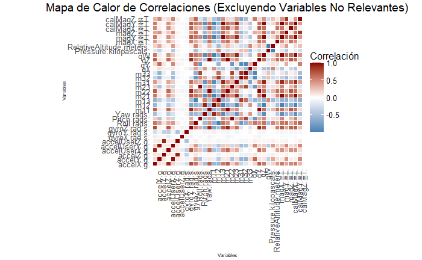

```r
library(ggplot2)
library(reshape2)

# Convertir la matriz en formato largo
corr_melted <- melt(cor_matrix)

# Crear el heatmap
ggplot(corr_melted, aes(x = Var1, y = Var2, fill = value)) +
  geom_tile(color = "white") +
  scale_fill_gradient2(low = "steelblue", high = "darkred", mid = "white", midpoint = 0, name = "Correlación") +
  theme_minimal(base_size = 6) +  # Aumentar el tamaño del texto
  theme(
    axis.text.x = element_text(angle = 90, hjust = 1, size = 10),
    axis.text.y = element_text(size = 10),
    plot.title = element_text(hjust = 0.5, size = 14),
    legend.text = element_text(size = 10),
    legend.title = element_text(size = 12)
  ) +
  labs(
    title = "Mapa de Calor de Correlaciones (Excluyendo Variables No Relevantes)",
    x = "Variables",
    y = "Variables"
  ) +
  coord_fixed()
```